# Geospatial/SAE workshop

Small area estimation

Josh Merfeld

October 2024

## Feature selection

- Let’s start with some example data I have
  - This comes from Malawi
    - Northern Malawi only (due to the size of the data)
  - And we’ll use it all day tomorrow!

```r
library(tidyverse)
surveycollapsed <- read_csv("saedata/ihs5ea.csv")
predictors <- read_csv("saedata/mosaikvars.csv")
```

## Observations?

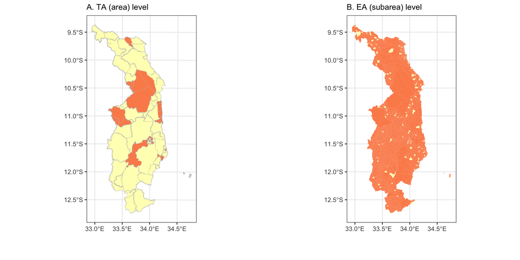

## Predictive features

- I also have a bunch of predictive features!
  - The data come from something called MOSAIKS, that we’ll discuss briefly tomorrow
  - In short, they are variables derived from satellite imagery
  - Take a look at this

```r
predictors
```

```
# A tibble: 2,911 × 501
    EA_CODE  mosaik1  mosaik2 mosaik3 mosaik4 mosaik5 mosaik6 mosaik7 mosaik8
      <dbl>    <dbl>    <dbl>   <dbl>   <dbl>   <dbl>   <dbl>   <dbl>   <dbl>
 1 10101001 0.00143  0.00242    0.632  0.0334  0.0684   0.223 0.00641  0.0753
 2 10101002 0.000659 0.000250   0.911  0.0468  0.0978   0.357 0.00359  0.127
 3 10101003 0.000657 0.000403   0.811  0.0373  0.0794   0.326 0.00285  0.100
 4 10101004 0.00102  0.000769   0.975  0.0578  0.111    0.369 0.00584  0.140
 5 10101005 0.000472 0.000351   0.815  0.0344  0.0668   0.381 0.00287  0.0947
 6 10101006 0.00107  0.000835   0.861  0.0496  0.122    0.315 0.00536  0.137
 7 10101007 0.00132  0.000842   1.13   0.0549  0.0999   0.594 0.00649  0.154
 8 10101008 0.00202  0.00182    1.05   0.0796  0.166    0.415 0.00953  0.179
 9 10101009 0.000445 0.000417   0.834  0.0332  0.0663   0.375 0.00278  0.0950
10 10101010 0.000720 0.000438   0.794  0.0367  0.0849   0.328 0.00377  0.109
# ℹ 2,901 more rows
# ℹ 492 more variables: mosaik9 <dbl>, mosaik10 <dbl>, mosaik11 <dbl>,
#   mosaik12 <dbl>, mosaik13 <dbl>, mosaik14 <dbl>, mosaik15 <dbl>,
#   mosaik16 <dbl>, mosaik17 <dbl>, mosaik18 <dbl>, mosaik19 <dbl>,
#   mosaik20 <dbl>, mosaik21 <dbl>, mosaik22 <dbl>, mosaik23 <dbl>,
#   mosaik24 <dbl>, mosaik25 <dbl>, mosaik26 <dbl>, mosaik27 <dbl>,
#   mosaik28 <dbl>, mosaik29 <dbl>, mosaik30 <dbl>, mosaik31 <dbl>, …
```

## We have a problem

```r
# this is how many subarea observations we have
nrow(surveycollapsed)
```

```
[1] 107
```

```r
# this is how many predictors we have
ncol(predictors)
```

```
[1] 501
```

- What’s the problem?
- It’s actually impossible to estimate a model with more predictors than observations!

## Another problem: overfitting

- There’s another problem, too
- If we have too many predictors, we can “overfit” the model
  - This means the model is too complex
  - It fits the data we have *too* well
  - This means it doesn’t generalize well to new data
- So we need to select the best predictors
  - What does “best” mean here?

## Generalizing out-of-sample

- We want to know what best predicts OUT of sample
- So we are going to set up our data to allow this:
  - We will split the data into X parts
  - A common number for X is 10, but let’s do 5

## Cross validation

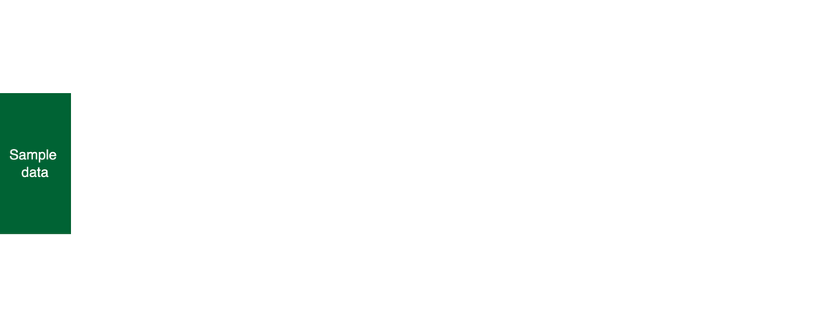

## Cross validation

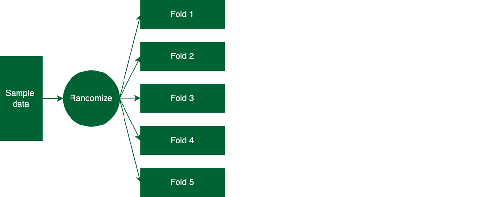

## Cross validation - random folds

```r
surveycollapsed$fold <- sample(1:5, nrow(surveycollapsed), replace = TRUE)
head(surveycollapsed)
```

```
# A tibble: 6 × 5
   EA_CODE   poor total_weights total_obs  fold
     <dbl>  <dbl>         <dbl>     <dbl> <int>
1 10101006 0.230          5690.        16     1
2 10101011 0.444          7614.        16     4
3 10101027 0.0947         9441.        16     3
4 10101033 0.376          7486.        16     2
5 10101039 0.600          9147.        16     5
6 10101054 0.497          5351.        16     5
```

## Cross validation

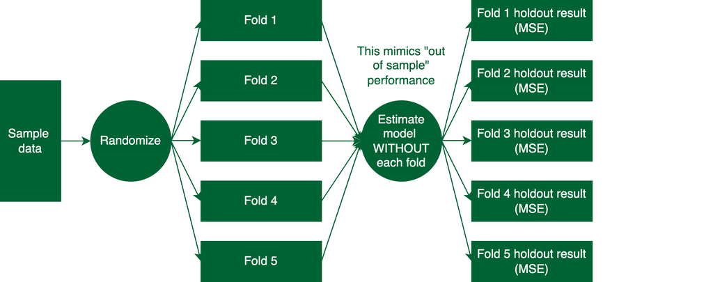

## Cross validation

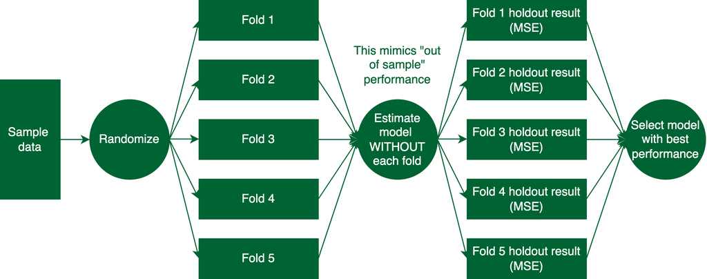

## But what “models” are we going to fit?

- What are the models we are going to fit?
  - We want a way to select the best predictors
  - This will reduce the number of predictors and prevent overfitting (we hope)
- We are going to use a method called LASSO (or lasso)
  - It’s an acronym: **L**east **A**bsolute **S**hrinkage and **S**election **O**perator
  - No details, but it’s a way to select the best predictors
    - It “penalizes” the coefficients of the predictors
  - `R` package `glmnet` does this for us

## The setup - with a transformed outcome

```r
library(glmnet)
set.seed(398465) # this is a random process, so we want to set the seed!

# we need to set up the data (combining the predictors and the outcome)
data <- surveycollapsed |>
  left_join(predictors, by = "EA_CODE")

# cv.glmnet will set up everything for us
lasso <- cv.glmnet(
  y = asin(sqrt(data$poor)), # the outcome
  x = data |> dplyr::select(starts_with("mosaik")) |> as.matrix(), # the predictors (as.matrix() is required)
  weights = data$total_weights, # the weights (sample weights)
  nfolds = 5) # number of folds (10 is the default)
lasso
```

```
Call:  cv.glmnet(x = as.matrix(dplyr::select(data, starts_with("mosaik"))),      y = asin(sqrt(data$poor)), weights = data$total_weights,      nfolds = 5)

Measure: Mean-Squared Error

     Lambda Index Measure       SE Nonzero
min 0.02030    26 0.04227 0.006409       6
1se 0.06493     1 0.04418 0.005811       0
```

## What have we done?

```r
lasso
```

```
Call:  cv.glmnet(x = as.matrix(dplyr::select(data, starts_with("mosaik"))),      y = asin(sqrt(data$poor)), weights = data$total_weights,      nfolds = 5)

Measure: Mean-Squared Error

     Lambda Index Measure       SE Nonzero
min 0.02030    26 0.04227 0.006409       6
1se 0.06493     1 0.04418 0.005811       0
```

- What are the different “models”?
  - Different values of lambda
  - In this case, the “best” lambda is 0.02030
  - Note that some people prefer to use the `1se` value (it is more conservative). No details today.

## Different values of lambda: different predictors!

```r
lasso
```

```
Call:  cv.glmnet(x = as.matrix(dplyr::select(data, starts_with("mosaik"))),      y = asin(sqrt(data$poor)), weights = data$total_weights,      nfolds = 5)

Measure: Mean-Squared Error

     Lambda Index Measure       SE Nonzero
min 0.02030    26 0.04227 0.006409       6
1se 0.06493     1 0.04418 0.005811       0
```

- At the “optimal” lambda, we have 6 predictors (non-zero coefficients)

## Choosing based on mean-squared error (MSE)

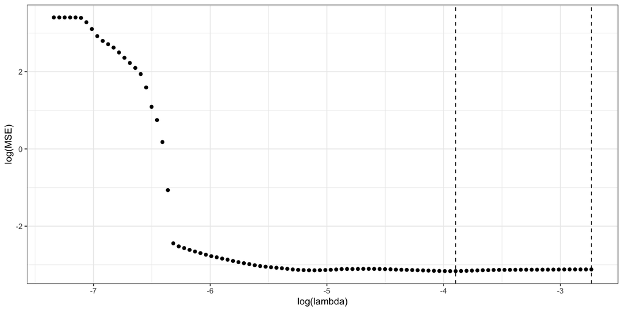

## Non-zero coefficients

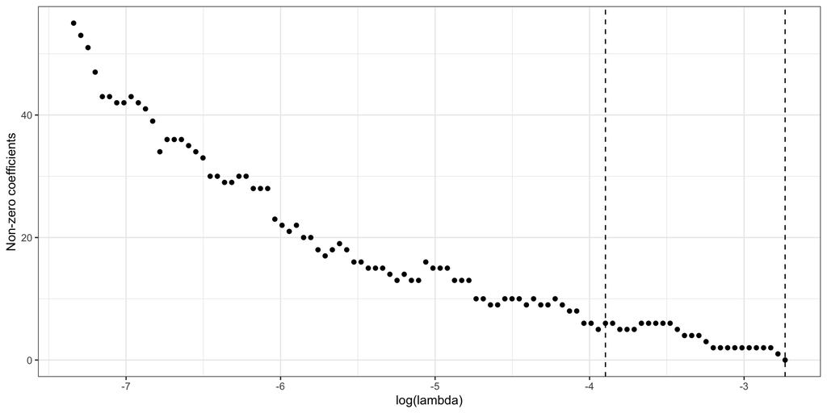

## Non-zero coefficients

```r
coef(lasso, s = "lambda.min")
```

```
501 x 1 sparse Matrix of class "dgCMatrix"
                       s1
(Intercept)   0.568658061
mosaik1       .
mosaik2       .
mosaik3       .
mosaik4       .
mosaik5       .
mosaik6       .
mosaik7       .
mosaik8       .
mosaik9       .
mosaik10      .
mosaik11      .
mosaik12      .
mosaik13      .
mosaik14      .
mosaik15      .
mosaik16      .
mosaik17      .
mosaik18      .
mosaik19      .
mosaik20      .
mosaik21      .
mosaik22      .
mosaik23      .
mosaik24      .
mosaik25      .
mosaik26      .
mosaik27      .
mosaik28      .
mosaik29      .
mosaik30      .
mosaik31      .
mosaik32      .
mosaik33      .
mosaik34      .
mosaik35      .
mosaik36      .
mosaik37      .
```

[output cut: 448 more lines]

```
mosaik486     .
mosaik487     .
mosaik488     .
mosaik489     .
mosaik490     .
mosaik491     .
mosaik492     .
mosaik493     .
mosaik494     .
mosaik495     .
mosaik496     .
mosaik497     .
mosaik498     .
mosaik499     .
mosaik500     .
```

## What we want: the non-zero variable names!

- Getting the names of the variables is more complicated than it should be

```r
# first, turn the coefs into a data.frame
coefs <- coef(lasso, s = "lambda.min") |>
  as.matrix() |>
  as.data.frame()
coefs
```

```
                       s1
(Intercept)   0.568658061
mosaik1       0.000000000
mosaik2       0.000000000
mosaik3       0.000000000
mosaik4       0.000000000
mosaik5       0.000000000
mosaik6       0.000000000
mosaik7       0.000000000
mosaik8       0.000000000
mosaik9       0.000000000
mosaik10      0.000000000
mosaik11      0.000000000
mosaik12      0.000000000
mosaik13      0.000000000
mosaik14      0.000000000
mosaik15      0.000000000
mosaik16      0.000000000
mosaik17      0.000000000
mosaik18      0.000000000
mosaik19      0.000000000
mosaik20      0.000000000
mosaik21      0.000000000
mosaik22      0.000000000
mosaik23      0.000000000
mosaik24      0.000000000
mosaik25      0.000000000
mosaik26      0.000000000
mosaik27      0.000000000
mosaik28      0.000000000
mosaik29      0.000000000
mosaik30      0.000000000
mosaik31      0.000000000
mosaik32      0.000000000
mosaik33      0.000000000
mosaik34      0.000000000
mosaik35      0.000000000
mosaik36      0.000000000
mosaik37      0.000000000
mosaik38      0.000000000
```

[output cut: 447 more lines]

```
mosaik486     0.000000000
mosaik487     0.000000000
mosaik488     0.000000000
mosaik489     0.000000000
mosaik490     0.000000000
mosaik491     0.000000000
mosaik492     0.000000000
mosaik493     0.000000000
mosaik494     0.000000000
mosaik495     0.000000000
mosaik496     0.000000000
mosaik497     0.000000000
mosaik498     0.000000000
mosaik499     0.000000000
mosaik500     0.000000000
```

## What we want: the non-zero variable names!

- Getting the names of the variables is more complicated than it should be

```r
# Now, create variable that is the name of the rows
coefs$variable <- rownames(coefs)
head(coefs)
```

```
                   s1    variable
(Intercept) 0.5686581 (Intercept)
mosaik1     0.0000000     mosaik1
mosaik2     0.0000000     mosaik2
mosaik3     0.0000000     mosaik3
mosaik4     0.0000000     mosaik4
mosaik5     0.0000000     mosaik5
```

```r
# non-zero rows
coefs <- coefs[coefs$s1!=0,]
# finally, the names of the variables
coefs$variable
```

```
[1] "(Intercept)" "mosaik39"    "mosaik234"   "mosaik277"   "mosaik280"
[6] "mosaik396"   "mosaik459"
```

## One more step: remove the Intercept!

- We don’t want the name of the intercept
  - All of the packages we use will add that automatically

```r
allvariables <- coefs$variable[-1]
allvariables
```

```
[1] "mosaik39"  "mosaik234" "mosaik277" "mosaik280" "mosaik396" "mosaik459"
```

## How do we use this with ebp?

- In EBP, we need a `formula`
- How do we turn this into a formula?
  - We need to add the outcome variable (poor) `and` combine the predictors with `+`

```r
ebpformula <- as.formula(paste("poor ~", paste(allvariables, collapse = " + ")))
ebpformula
```

```
poor ~ mosaik39 + mosaik234 + mosaik277 + mosaik280 + mosaik396 +
    mosaik459
```

## Finally: estimating the model

```r
library(povmap) # I like to use povmap instead of emdi (personal preference)
# get "area" variable
predictors$TA_CODE <- substr(predictors$EA_CODE, 1, 5)
data$TA_CODE <- substr(data$EA_CODE, 1, 5)
ebp <- ebp(fixed = ebpformula, # the formula
  pop_data = predictors, # the population data
  pop_domains = "TA_CODE", # the domain (area) name in the population data
  smp_data = data, # the sample data
  smp_domains = "TA_CODE", # the domain (area) name in the sample data
  transformation = "arcsin", # I'm going to use the arcsin transformation
  weights = "total_weights", # sample weights
  weights_type = "nlme", # weights type
  MSE = TRUE, # variance? yes please
  L = 0) # this is a new thing in povmap: "analytical" point estimates. much faster!
```

```
Time difference of 0.54 secs
```

```r
summary(ebp)
```

```
Empirical Best Prediction

Call:
 ebp(fixed = poor ~ mosaik39 + mosaik234 + mosaik277 + mosaik280 +
    mosaik396 + mosaik459, pop_data = predictors, pop_domains = "TA_CODE",
    smp_data = data, smp_domains = "TA_CODE", L = 0, transformation = "arcsin",
    MSE = TRUE, weights = "total_weights", weights_type = "nlme")

Out-of-sample domains:  27
In-sample domains:  49
Out-of-sample subdomains:  0
In-sample subdomains:  0

Sample sizes:
Units in sample:  107
Units in population:  2911
                   Min. 1st Qu. Median      Mean 3rd Qu. Max.
Sample_domains        1     1.0      2  2.183673       3    7
Population_domains    1     5.5     18 38.302632      44  300

Explanatory measures for the mixed model:
 Marginal_R2 Conditional_R2 Marginal_Area_R2 Conditional_Area_R2
   0.2552368      0.4115571        0.4196524           0.6605383

Residual diagnostics for the mixed model:
                Skewness Kurtosis Shapiro_W    Shapiro_p
Error         -0.5081831 3.993441 0.9761079 5.063839e-02
Random_effect  0.1855229 6.703526 0.8687609 1.234483e-06

Estimated variance of random effects:
                 Variance
Error         0.028541022
Random_effect 0.007581942

ICC:  0.2098926

Transformation:
 Transformation Shift_parameter
         arcsin               0
```

## Some results

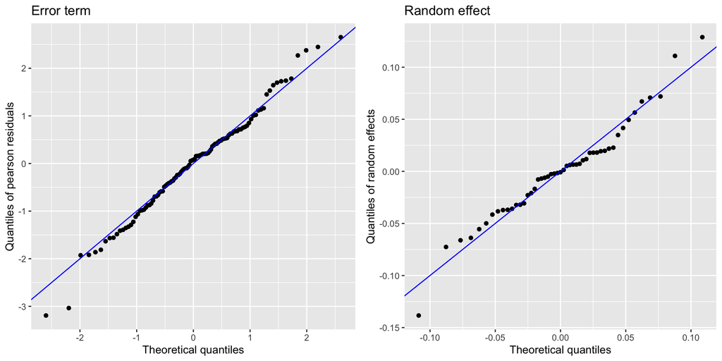

```
Press [enter] to continue
```

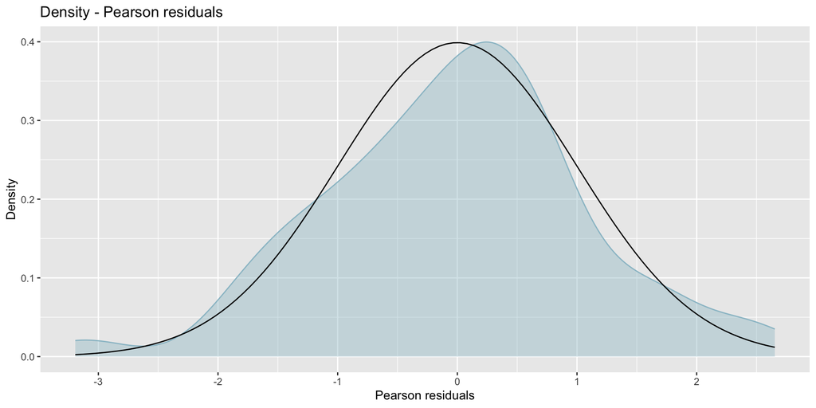

```
Press [enter] to continue
```

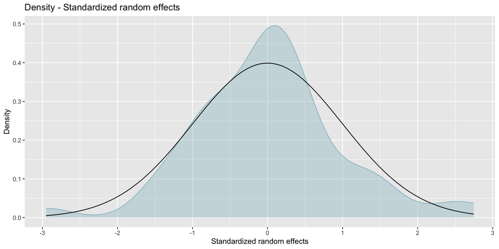

```
Press [enter] to continue
```

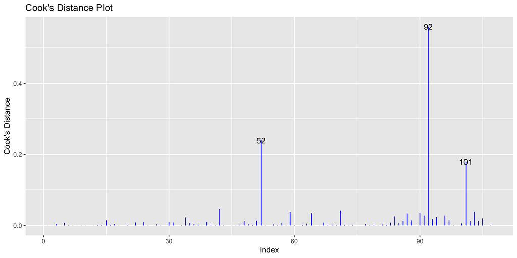

```r
plot(ebp)
```

## Some results

```r
summary(ebp)
```

```
Empirical Best Prediction

Call:
 ebp(fixed = poor ~ mosaik39 + mosaik234 + mosaik277 + mosaik280 +
    mosaik396 + mosaik459, pop_data = predictors, pop_domains = "TA_CODE",
    smp_data = data, smp_domains = "TA_CODE", L = 0, transformation = "arcsin",
    MSE = TRUE, weights = "total_weights", weights_type = "nlme")

Out-of-sample domains:  27
In-sample domains:  49
Out-of-sample subdomains:  0
In-sample subdomains:  0

Sample sizes:
Units in sample:  107
Units in population:  2911
                   Min. 1st Qu. Median      Mean 3rd Qu. Max.
Sample_domains        1     1.0      2  2.183673       3    7
Population_domains    1     5.5     18 38.302632      44  300

Explanatory measures for the mixed model:
 Marginal_R2 Conditional_R2 Marginal_Area_R2 Conditional_Area_R2
   0.2552368      0.4115571        0.4196524           0.6605383

Residual diagnostics for the mixed model:
                Skewness Kurtosis Shapiro_W    Shapiro_p
Error         -0.5081831 3.993441 0.9761079 5.063839e-02
Random_effect  0.1855229 6.703526 0.8687609 1.234483e-06

Estimated variance of random effects:
                 Variance
Error         0.028541022
Random_effect 0.007581942

ICC:  0.2098926

Transformation:
 Transformation Shift_parameter
         arcsin               0
```

## Some results

```r
estimators(ebp, "Mean", MSE = TRUE, CV = TRUE)
```

```
Indicator/s: Mean
   Domain      Mean    Mean_MSE   Mean_CV
1   10101 0.3669687 0.002629563 0.1397375
2   10102 0.3526612 0.004691803 0.1942282
3   10103 0.2829257 0.005993879 0.2736412
4   10104 0.3255265 0.013896106 0.3621264
5   10105 0.3564514 0.005792373 0.2135147
6   10106 0.3747787 0.005655064 0.2006522
7   10107 0.3518191 0.006464604 0.2285344
8   10108 0.3545512 0.010294990 0.2861765
9   10109 0.3971006 0.005946677 0.1941944
10  10110 0.2786403 0.029650480 0.6179764
11  10120 0.3480978 0.014268712 0.3431556
12  10201 0.3514189 0.003464771 0.1674990
13  10202 0.3344865 0.004468171 0.1998418
```

[output cut: 63 more lines]

## Let’s put those results on a map!

```r
estimates <- estimators(ebp, "Mean", MSE = TRUE, CV = TRUE)$ind
# load mw3 shapefile
mw3 <- read_sf("saedata/mw3.shp")
mw3 <- mw3 |>
  left_join(estimates, by = c("TA_CODE" = "Domain"))
```

## Let’s put those results on a map!

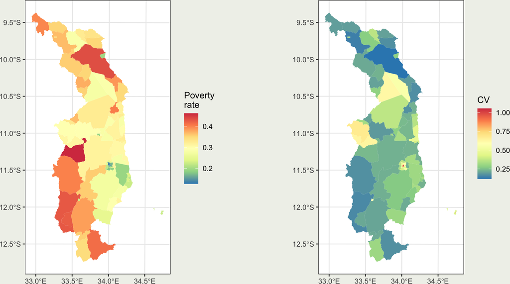

## What does this look like if we DON’T transform?

```r
ebpnotransform <- ebp(fixed = ebpformula, # the formula
  pop_data = predictors, # the population data
  pop_domains = "TA_CODE", # the domain (area) name in the population data
  smp_data = data, # the sample data
  smp_domains = "TA_CODE", # the domain (area) name in the sample data
  transformation = "no",
  weights = "total_weights", # sample weights
  weights_type = "nlme", # weights type
  MSE = TRUE, # variance? yes please
  L = 0) # this is a new thing in povmap: "analytical" point estimates. much faster!
```

```
Time difference of 0.55 secs
```

## The residuals

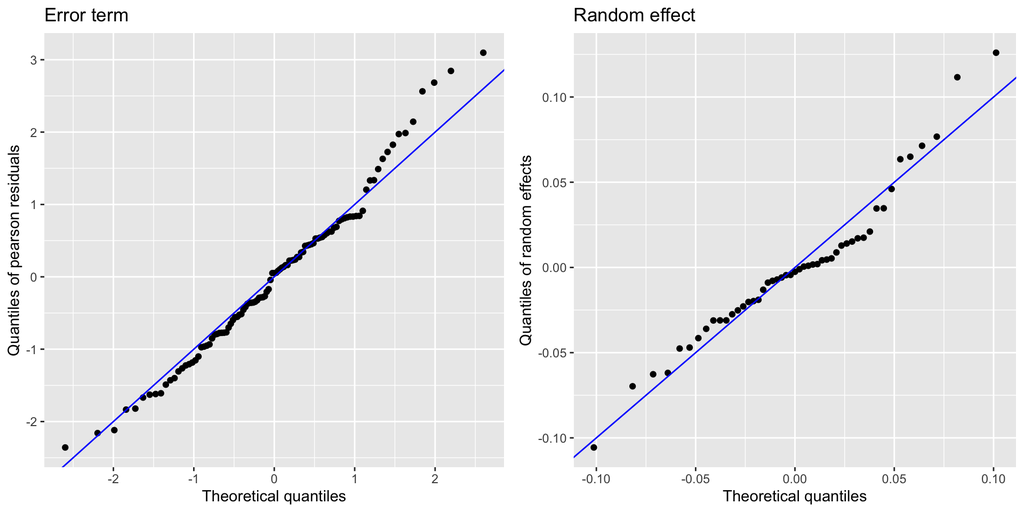

```
Press [enter] to continue
```

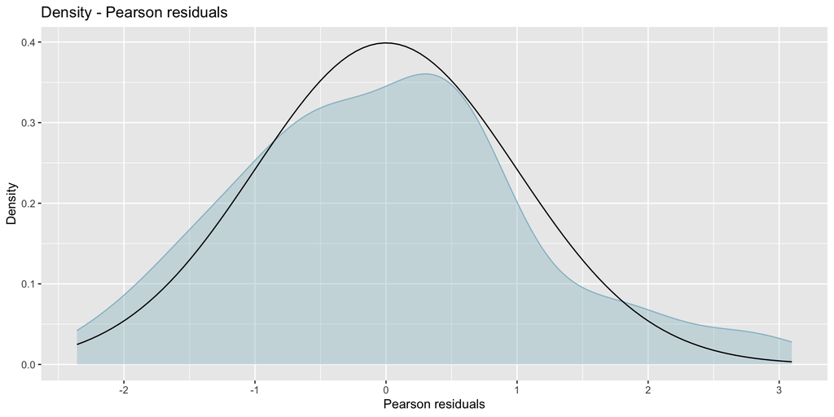

```
Press [enter] to continue
```

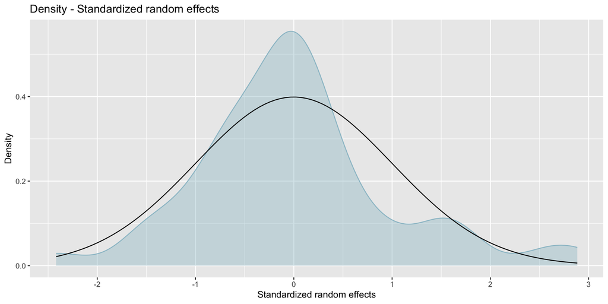

```
Press [enter] to continue
```

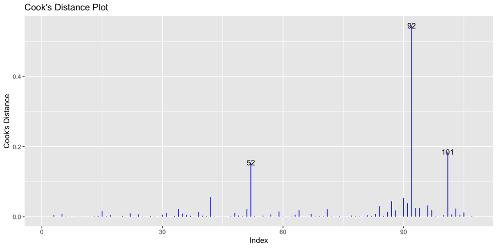

```r
plot(ebpnotransform)
```

## Comparing the models

**No transformation**

```
Empirical Best Prediction

Call:
 ebp(fixed = poor ~ mosaik39 + mosaik234 + mosaik277 + mosaik280 +
    mosaik396 + mosaik459, pop_data = predictors, pop_domains = "TA_CODE",
    smp_data = data, smp_domains = "TA_CODE", L = 0, transformation = "no",
    MSE = TRUE, weights = "total_weights", weights_type = "nlme")

Out-of-sample domains:  27
In-sample domains:  49
Out-of-sample subdomains:  0
In-sample subdomains:  0

Sample sizes:
Units in sample:  107
Units in population:  2911
                   Min. 1st Qu. Median      Mean 3rd Qu. Max.
Sample_domains        1     1.0      2  2.183673       3    7
Population_domains    1     5.5     18 38.302632      44  300

Explanatory measures for the mixed model:
 Marginal_R2 Conditional_R2 Marginal_Area_R2 Conditional_Area_R2
   0.2140398      0.4022848         0.363542           0.6916272

Residual diagnostics for the mixed model:
                Skewness Kurtosis Shapiro_W    Shapiro_p
Error         0.08332729 3.198589 0.9944134 9.448568e-01
Random_effect 0.77049434 6.410903 0.8521690 3.334349e-07

Estimated variance of random effects:
                 Variance
Error         0.018896174
Random_effect 0.005951178

ICC:  0.2395095

Transformation: No transformation
```

**Arcsin transformation**

```
Empirical Best Prediction

Call:
 ebp(fixed = poor ~ mosaik39 + mosaik234 + mosaik277 + mosaik280 +
    mosaik396 + mosaik459, pop_data = predictors, pop_domains = "TA_CODE",
    smp_data = data, smp_domains = "TA_CODE", L = 0, transformation = "arcsin",
    MSE = TRUE, weights = "total_weights", weights_type = "nlme")

Out-of-sample domains:  27
In-sample domains:  49
Out-of-sample subdomains:  0
In-sample subdomains:  0

Sample sizes:
Units in sample:  107
Units in population:  2911
                   Min. 1st Qu. Median      Mean 3rd Qu. Max.
Sample_domains        1     1.0      2  2.183673       3    7
Population_domains    1     5.5     18 38.302632      44  300

Explanatory measures for the mixed model:
 Marginal_R2 Conditional_R2 Marginal_Area_R2 Conditional_Area_R2
   0.2552368      0.4115571        0.4196524           0.6605383

Residual diagnostics for the mixed model:
                Skewness Kurtosis Shapiro_W    Shapiro_p
Error         -0.5081831 3.993441 0.9761079 5.063839e-02
Random_effect  0.1855229 6.703526 0.8687609 1.234483e-06

Estimated variance of random effects:
                 Variance
Error         0.028541022
Random_effect 0.007581942

ICC:  0.2098926

Transformation:
 Transformation Shift_parameter
         arcsin               0
```

## One more thing: we can go higher!

```r
predictors$dist <- substr(predictors$TA_CODE, 1, 3)
data$dist <- substr(data$TA_CODE, 1, 3)
ebpnotransform <- ebp(fixed = ebpformula, # the formula
  pop_data = predictors, # the population data
  pop_domains = "TA_CODE", # the domain (area) name in the population data
  aggregate_to = "dist", # aggregate to district!
  smp_data = data, # the sample data
  smp_domains = "TA_CODE", # the domain (area) name in the sample data
  transformation = "no",
  weights = "total_weights", # sample weights
  weights_type = "nlme", # weights type
  MSE = TRUE, # variance? yes please
  L = 0) # this is a new thing in povmap: "analytical" point estimates. much faster!
```

```
Time difference of 0.49 secs
```